# Incorporating age-based disease severity

Irena Papst

Last updated: 31 Mar 2021 at 10:25

# Age-based differences in outcomes

## Is the code vectorized already?

What if we just update the scalar params involved in disease severity with a vector? Will the code run as expected?

Provide a vectorized parameter with a manual update and see what make_ratemat does. Put the entire population the state where the vectorized parameter is in the outflow, and shut off the next outflow(s). Compare to base sim with the same setup. Do we get what we expect?

Try vectorizing $\mu$, the fraction of symptomatic cases that are mild:

```r
age_cat <- mk_agecats(0, 80, da = 30)
n <- length(age_cat)
Ni <- 1e6
Nvec <- rep(Ni, n)
end_date <- "2020-08-01"

## set up base (non-ageified) params and state
base_params <- update(read_params("PHAC_testify.csv")
                      , N = sum(Nvec)
                      , testing_intensity = 0
                      , beta0 = 2
                      )
base_state <- make_state(N = base_params[["N"]],
                         E0 = 0)
## put everyone in the presymptomatic compartment (testing tweak to mu =
## proportion of symptomatic cases that are severe a.k.a. require acute care)
base_state[["Ip"]] <- base_state[["S"]]
base_state[["S"]] <- 0

## tweak base params to make it easier to check things are working well
## set recovery rate from presymptomatic state to 1, so overall rate will just
## be mu or 1-mu, and recovery from mild and severe infection to 0, to stop
## outflow from Ip compartment
base_params <- update(base_params,
                      gamma_p = 1,
                      gamma_m = 0,
                      gamma_s = 0)

age_params <- expand_params_age(base_params, age_cat = age_cat)
age_state <- expand_state_age(base_state, age_cat = age_cat)

## update mu in age_params as a vector (one for each age)
age_params[["mu"]] <- c(0.2, 0.5, 0.7)

## make rate matrix
age_ratemat <- make_ratemat(state = age_state, params = age_params)

age_ratemat[grepl("Ip", rownames(age_ratemat)), grepl("I[ms]", colnames(age_ratemat))]
```

```
##           to
## from       Im_0-29 Is_0-29 Im_30-59 Is_30-59 Im_60+ Is_60+
##   Ip_0-29      0.2     0.8      0.0      0.0    0.0    0.0
##   Ip_30-59     0.0     0.0      0.5      0.5    0.0    0.0
##   Ip_60+       0.0     0.0      0.0      0.0    0.7    0.3
```

So the ratemat looks ageifed, but let’s see what happens in simulations:

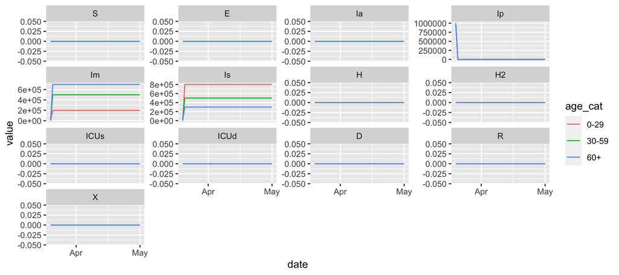

```r
age_res <- run_sim(params = age_params,
                   state = age_state,
                   condense = FALSE)

plot_res_by_state(age_res)
```

Compared to base sim with a single $\mu$ value:

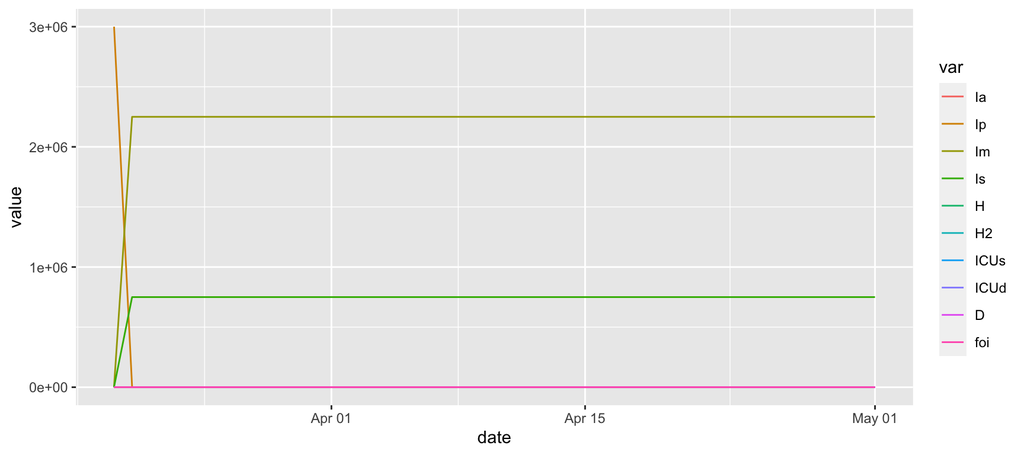

```r
base_params[["mu"]] <- 0.75

base_res <- run_sim(base_params, base_state, condense = FALSE)

plot(base_res)
```

Looks good! That was just for $\mu$, the fraction of a symptomatic cases that are mild, which is equal to $1-\mathbb{P}(\rm{hosp} | \rm{KI})$ from the first COVID age paper. The machinery under the hood is the same for all other non-FOI-related parameters in `make_ratemat()`, so we really shouldn’t have to do any further checks, but just to be absolutely sure, let’s see whether the parameters related to $\mathbb{P}(\rm{death} | \rm{hosp})$ are just as easily vectorized:

- $\phi_1$, which controls split from $I_s$ to either $H$ (fraction $\phi_1$) and $ICU_{s|d}$ (combined fraction $1-\phi_1$);
- $\phi_2$, which controls the split from $I_s$ to either $ICU_s$ (fraction $1-\phi_2$) and $ICU_d$ (fraction $\phi_2$).

For $\phi_1$:

```r
## set up base (non-ageified) params and state
base_params <- update(read_params("PHAC_testify.csv")
                      , N = sum(Nvec)
                      , testing_intensity = 0
                      , beta0 = 2
                      )
base_state <- make_state(N = base_params[["N"]],
                         E0 = 0)

## adjust state to isolate compartment for which we're vectorizing outflow
## parameters
base_state[["Is"]] <- base_state[["S"]]
base_state[["S"]] <- 0

## check update
# base_state

## adjust base parameters to isolate action of vectorization
base_params <- update(base_params,
                      phi1 = 0.75,
                      phi2 = 0,  ## to isolate phi_1
                      gamma_a = 0,
                      gamma_p = 0,
                      gamma_m = 0,
                      gamma_s = 1,
                      psi1 = 0,
                      psi2 = 0,
                      psi3 = 0,
                      rho = 0)

## check update
# base_params[grepl("phi|gamma|psi", names(base_params))]

age_params <- expand_params_age(base_params, age_cat = age_cat)
age_state <- expand_state_age(base_state, age_cat = age_cat)

## update mu in age_params as a vector (one for each age)
age_params[["phi1"]] <- c(0.1, 0.4, 0.8)

## make rate matrix
age_ratemat <- make_ratemat(state = age_state, params = age_params)

age_ratemat[grepl("Is", rownames(age_ratemat)), grepl("H_|ICU[sd]", colnames(age_ratemat))]
```

```
##           to
## from       H_0-29 ICUs_0-29 ICUd_0-29 H_30-59 ICUs_30-59 ICUd_30-59 H_60+
##   Is_0-29     0.1       0.9         0     0.0        0.0          0   0.0
##   Is_30-59    0.0       0.0         0     0.4        0.6          0   0.0
##   Is_60+      0.0       0.0         0     0.0        0.0          0   0.8
##           to
## from       ICUs_60+ ICUd_60+
##   Is_0-29       0.0        0
##   Is_30-59      0.0        0
##   Is_60+        0.2        0
```

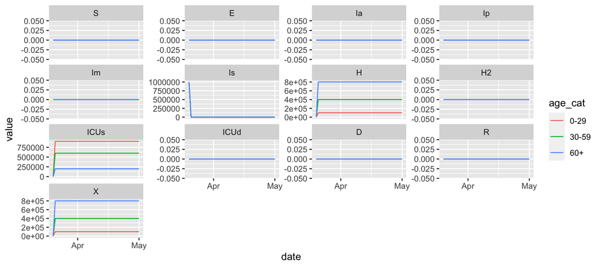

```r
## age sim
age_res <- run_sim(params = age_params,
                   state = age_state,
                   condense = FALSE)

plot_res_by_state(age_res)
```

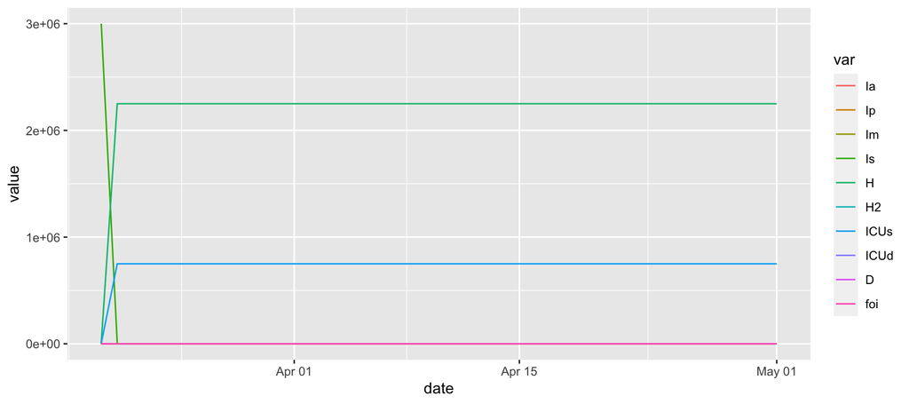

```r
base_res <- run_sim(base_params, base_state, condense = FALSE)

plot(base_res)
```

For $\phi_2$:

```r
## adjust base parameters to isolate action of vectorization
base_params <- update(base_params,
                      phi1 = 0, ## to isolate phi_2
                      phi2 = 0.5)

## check update
# base_params[grepl("phi|gamma|psi", names(base_params))]

age_params <- expand_params_age(base_params, age_cat = age_cat)
age_state <- expand_state_age(base_state, age_cat = age_cat)

## update mu in age_params as a vector (one for each age)
age_params[["phi2"]] <- c(0.25, 0.55, 0.65)

## make rate matrix
age_ratemat <- make_ratemat(state = age_state, params = age_params)

age_ratemat[grepl("Is", rownames(age_ratemat)), grepl("ICU[sd]", colnames(age_ratemat))]
```

```
##           to
## from       ICUs_0-29 ICUd_0-29 ICUs_30-59 ICUd_30-59 ICUs_60+ ICUd_60+
##   Is_0-29       0.75      0.25       0.00       0.00     0.00     0.00
##   Is_30-59      0.00      0.00       0.45       0.55     0.00     0.00
##   Is_60+        0.00      0.00       0.00       0.00     0.35     0.65
```

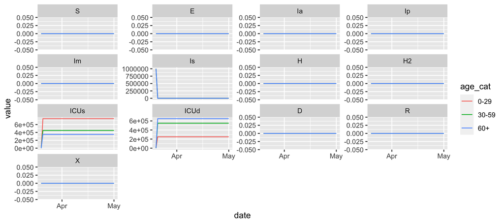

```r
## age sim
age_res <- run_sim(params = age_params,
                   state = age_state,
                   condense = FALSE)

plot_res_by_state(age_res)
```

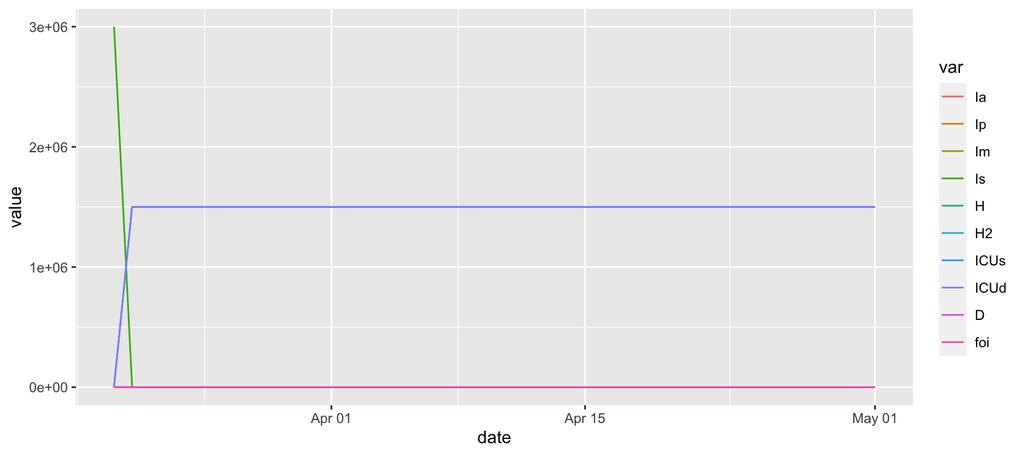

```r
base_res <- run_sim(base_params, base_state, condense = FALSE)

plot(base_res)
```

OK, everything looks good! Let’s try a full sim for fun:

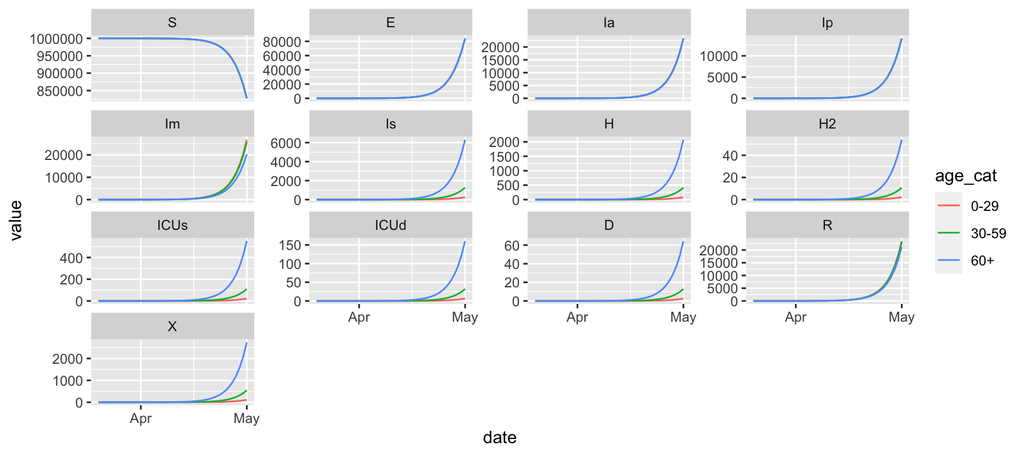

```r
base_params <- update(read_params("PHAC_testify.csv")
                      , N = sum(Nvec)
                      , testing_intensity = 0
                      )
base_state <- make_state(params = base_params)

age_params <- expand_params_age(
  base_params,
  age_cat
)

age_state <- expand_state_age(base_state, age_cat)

## losely based on covid age paper
age_params[["mu"]] <- c(0.99, 0.95, 0.75)

age_res <- run_sim(age_params, age_state, condense = FALSE)

plot_res_by_state(age_res)
```

Looks good! Let’s try the same thing but turning on age-based differences in transmission (via heterogeneity in contacts and population size):

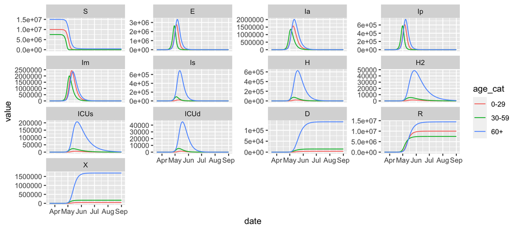

```r
## set up age categories
n <- length(age_cat)

## uniform pop, non-unif contacts
beta0 <- c(2, 3, 3/2)
Nvec <- rep(5e6, 3)
pmat <- matrix(c(4/10, 4/30, 8/15,
                 2/10, 23/30, 3/15,
                 4/10, 1/10, 4/15),
               nrow = 3,
               dimnames = list(age_cat, age_cat))

## rescale pop to be non-unif without breaking balance
total_contacts <- beta0*Nvec
beta0 <- c(1, 2, 0.5)
Nvec <- total_contacts/beta0

# print("balance condition implies the following matrix should be symmetric:")
# total_contacts_between_ages <- (beta0*Nvec)*pmat
# print(total_contacts_between_ages)
# print("is symmetric?")
# print(isSymmetric(total_contacts_between_ages))

age_params[["beta0"]] <- beta0
age_params[["N"]] <- Nvec
age_params[["pmat"]] <- pmat

## update state based on new population size
age_state <- expand_state_age(
  make_state(N = sum(age_params[["N"]]), E0 = 0),
  age_cat = age_cat
)

## tweak age state
E0 <- c(0,5,0)
age_state[grep("S", names(age_state))] <- Nvec-E0
age_state[grep("E", names(age_state))] <- E0

## losely based on covid age paper
age_params[["mu"]] <- c(0.99, 0.95, 0.75)

age_res <- run_sim(age_params, age_state,
                   end_date = "2020-09-01",
                   condense = FALSE)

plot_res_by_state(age_res)
```

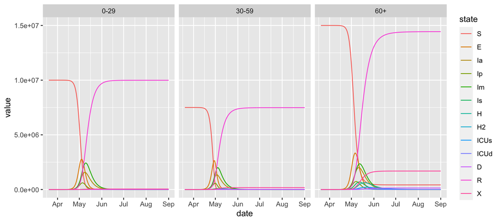

```r
plot_res_by_age(age_res)
```

Great!